# Praca domowa 1

Dominik Rafacz

October 13, 2018

W niniejszej pracy domowej zwizualizuję dane prezentowane w poniższym artykule:

(https://www.gry-online.pl/S013.asp?ID=111470)

Artykuł ten zawiera informacje o 10 filmach, które zarobiły najwięcej w USA w weekend 5-7 października bieżącego roku. Poza tą informacją dane informują nas również, ile każdy z tych filmów zarobił w USA łącznie (tzn. od daty premiery) oraz ile zarobił łącznie na całym świecie.

Będziemy korzystać z biblioteki $\tt{ggplot2}$ do tworzenia wykresów oraz pomocniczo z biblioteki $\tt{reshape}$, która pomoże przygotwać nam dane.

```r
library(ggplot2)
library(reshape)
```

Najpierw ładujemy dane zapisane w oddzielnym pliku:

```r
load("box_office.rda")
```

Następnie dane musimy przygotować - we wczytanej ramce danych każdy film posiada trzy liczbowe wartości i by móc zaprezentować je na wykresie słupkowym, użyjemy funkcji $\tt{melt}$ z pakietu $\tt{reshape}$, aby format danych był łatwiejszy do wyświetlenia za pomocą funkcji z pakiegu $\tt{ggplot2}$. Ponadto odpowiednio posortujemy wyjściową ramkę i zapiszemy w zmiennej porządek, w jakim chcemy prezentować słupki.

```r
# Rozbicie ramki danych względem zmiennych
box_office_long <- melt(box_office, id = "tytul", measure = c("przychod_weekendowy_w_USA",
                                                              "laczny_przychod_w_USA",
                                                              "laczny_przychod_na_swiecie"))
box_office_long <- box_office_long[order(box_office_long$variable, decreasing = TRUE), ]
ord <- order(box_office$przychod_weekendowy_w_USA, decreasing = TRUE)
```

Wreszcie - rysujemy wykres:

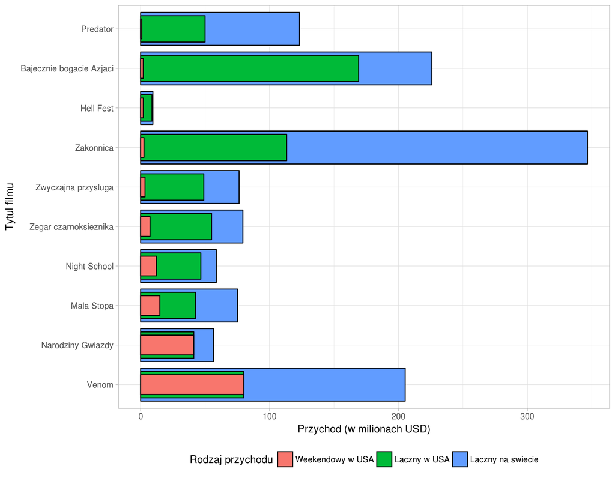

```r
ggplot(data = box_office_long, aes(x = reorder(tytul, rep(ord, 3)), fill = variable, y = value)) +
  geom_col(position = position_identity(),
           width = (as.integer(factor(box_office_long$variable))+2)/6,
           col="black") +
  scale_fill_discrete(name="Rodzaj przychodu",
                      labels=c("Weekendowy w USA",
                               "Laczny w USA",
                               "Laczny na swiecie")) +
  theme_light() +
  theme(legend.position="bottom") +
  xlab("Tytul filmu") +
  ylab("Przychod (w milionach USD)") +
  coord_flip()
```

Używamy wykresu słupkowego z nakładającymi się na siebie słupkami dla każdego filmu - zdecydowałem się na takie rozwiązanie, ponieważ dobrze obrazuje ono względną wielkość poszczególnych rodzajów przychodu każdego filmu, a także pozwala łatwo je porównać pomiędzy filmami.